# intertidal_analysis_short

tena

# 1 Overview

This document:

- Loads and merges pH/TA/nutrients and fDOM datasets
- Cleans data and applies outlier handling (IQR rule)
- Summarizes by habitat and diel period
- Creates PCA for seasonal drivers
- Plots relationships between variables to visualize processes
- Visualizes diel and habitat patterns (boxplots)

# 2 Setup

```r
library(tidyverse)
library(patchwork) # combine plots
library(rstatix)
library(car)
library(ggrepel) # prevent overlapping text
library(here) # for collaboration across folders
library(lubridate) # for date/time
library(kableExtra) # create tables
library(emmeans) # for pairwise comparisons
library(agricolae) # HSD test
library(lme4) # random effects
library(paletteer) # color palettes
library(ggh4x) # adds facet_grid2
#library(performance)
#library(MuMIn)
#library(rsample)
#library(yardstick)
library(ggnewscale) # multiple color scales on one plot
library(vegan) # for permanova
library(lmerTest) # random effects
library(maps) # for CA map
library(gt) # table
library(heplots) # boxM manova test

# Global plot theme
theme_set(theme_bw(base_size = 12))
```

## 2.1 Paths & Parameters

```r
keep_times <- params$keep_times
control_label <- params$control_label
```

# 3 Data Loading & Merging

This section loads both fDOM and pH/nutrients CSVs, parses dates, and joins on shared identifiers. We keep all samples, regardless of missing data (`full_join`).

```r
load_ok <- TRUE
tryCatch({
  data_ph <- read_csv(here::here("Data","Biogeochemistry","pHProbe_Data_calculated.csv"), na = c("NA", ""), show_col_types = FALSE)
    #mutate(Sampling_Date = lubridate::mdy(Sampling_Date))
  data_fdom <- read_csv(here::here("Data","Biogeochemistry","fDOM_clean.csv"), na = c("NA", ""), show_col_types = FALSE) %>%
    mutate(Sampling_Date = lubridate::mdy(Sampling_Date))
  data_tidal <- read_csv(here::here("Data","tidal_exchange.csv")) %>%
    mutate(Sampling_Date = lubridate::mdy(Sampling_Date))

  data_merged <- full_join(
    data_ph,
    data_fdom,
    by = c("UniqueID", "Benthos", "Quad_ID", "Day_Night", "Sampling_Date", "Sampling_Time","Season")
  ) %>%
    mutate(Humic = UVHumic+VisibleHumic+MarineHumic,# make a column for humics
           Prot = Tryptophan+Tyrosine, # make a column for proteinaceaus fDOM
           NOx = NO3+NO2 # make a column of total N
           )
  data_merged <- data_merged %>%
    left_join(data_tidal, by = c("Sampling_Date", "Day_Night"))

  cat("Data loaded and merged successfully.\n")
  cat("Total merged samples:", nrow(data_merged), "\n")
}, error = function(e){
  load_ok <<- FALSE
  message("Error loading or merging files. Please check file paths and names.")
  message(e)
})
```

```
## Data loaded and merged successfully.
## Total merged samples: 332
```

```r
stopifnot(load_ok)

sessile <- read_csv(here("Data","Community_Composition","sessile_data.csv"))
sessile_function <-read_csv(here("Data","Community_Composition","SessileFunctional.csv"))

mobile <- read_csv(here("Data","Community_Composition","mobile_data.csv"))
mobile_function <-read_csv(here("Data","Community_Composition","MobileFunctional.csv"))

# bring in HOBO data, need to trim to experimental dates
temperature <- bind_rows(
  read_csv(here("Data","Temperature","Spring_2024", "detided", "TempLight_Spring.csv")) %>%
    filter(datetime >= as.Date("2024-04-03") &
            datetime <= as.Date("2024-05-05")) %>%
    mutate(Season = "Spring"),
  read_csv(here("Data","Temperature","Fall_2023", "detided", "TempLight_Fall.csv")) %>%
    filter(datetime >= as.Date("2023-10-21") &
            datetime <= as.Date("2023-11-03")) %>%
    mutate(Season = "Fall")
) %>%
   mutate(
      Benthos = case_when(
      str_detect(plot, "^B")  ~ "Barnacle",
      str_detect(plot, "^M")  ~ "Mussel",
      str_detect(plot, "^P")  ~ "Surfgrass",
      str_detect(plot, "^RW") ~ "Rockweed",
      TRUE ~ NA_character_
      )
    )

cuti <- bind_rows(read_csv(here("Data","CUTI_daily.csv")) %>%
  mutate(Date = make_date(year, month, day)) %>%
  filter(Date >= as.Date("2024-04-03") &
            Date <= as.Date("2024-05-05")) %>%
  mutate(Season = "Spring") %>%
  select("Date","34N", "Season"),
  read_csv(here("Data","CUTI_daily.csv")) %>%
  mutate(Date = make_date(year, month, day)) %>%
  filter(Date >= as.Date("2023-10-21") &
            Date <= as.Date("2023-11-03")) %>%
  mutate(Season = "Fall")%>%
  select("Date","34N", "Season")) %>%
  rename("index" = "34N")

temp <- bind_rows(read_csv(here("Data","wave_height_2024.csv")) %>%
            mutate(Date = make_datetime(YY, MM, DD, hh, mm)) %>%
            filter(Date >= as.Date("2024-04-03") &
            Date <= as.Date("2024-05-05")) %>%
            mutate(Season = "Spring"),
          read_csv(here("Data","wave_height_2023.csv")) %>%
            mutate(Date = make_datetime(YY, MM, DD, hh, mm)) %>%
            filter(Date >= as.Date("2023-10-21") &
            Date <= as.Date("2023-11-03")) %>%
            mutate(Season = "Fall"))
```

# 4 Cleaning & Pre-processing

We declare variable sets for identifiers, water chemistry, nutrients, and fDOM components. We retain only **Dawn** and **Dusk** samples, coerce numeric columns, set factor orders, drop NA grouping levels, and apply the **1.5×IQR rule** as a conservative outlier filter (replacing outliers with `NA`).

```r
# Identifier variables
id_vars <- c("UniqueID", "Season", "Benthos", "Quad_ID", "Day_Night", "Sampling_Date", "Tide")

# Water chemistry variables (from pH probe file)
water_chem_vars <- c("Salinity", "pH", "TempInSitu", "TA")

# Nutrient variables (from pH probe file)
nutrient_vars <- c("NO3", "PO4", "SIL", "NO2", "NH4", "NOx")

# fDOM variables (from fDOM file)
#fdom_vars <- c("UVHumic", "Tyrosine", "VisibleHumic", "MarineHumic",
#               "Tryptophan", "FulvicAcid", "BIX", "HIX", "FI", "M_to_C")

# reduced variables
fdom_vars <- c("Humic","Prot", "BIX", "HIX", "M_to_C")

all_numeric_vars <- c(water_chem_vars, nutrient_vars, fdom_vars)

# only vars of interest

less_vars <- c("pH", "NOx", "NH4", "HIX")

# Helper to IQR-filter a numeric vector (returning NA for outliers)
iqr_filter <- function(x){
  if(!is.numeric(x)) return(x)
  q1 <- quantile(x, 0.25, na.rm = TRUE)
  q3 <- quantile(x, 0.75, na.rm = TRUE)
  iqr <- q3 - q1
  lo <- q1 - 1.5 * iqr
  hi <- q3 + 1.5 * iqr
  ifelse(x < lo | x > hi, NA_real_, x)
}

# Cleaned dataset
data_clean <- data_merged %>%
  filter(Day_Night %in% keep_times) %>%
  select(-M_to_C) %>%
  mutate(M_to_C = MarineHumic / VisibleHumic) %>%
  select(all_of(id_vars), any_of(all_numeric_vars)) %>%
  mutate(across(all_of(all_numeric_vars), as.numeric)) %>%
  mutate(
    Benthos  = factor(Benthos, levels = c("Open Ocean", "Rockweed", "Surfgrass", "Barnacle", "Mussel")),
    Day_Night = factor(Day_Night, levels = c("Dawn", "Dusk"))
  ) %>%
  drop_na(Benthos, Day_Night) %>%
  mutate(across(all_of(all_numeric_vars), iqr_filter)) %>% #iqr filter
  mutate(sample_type = if_else(Benthos == "Open Ocean",
                                   "Surface Water", "Foundation Species"))

levels(data_clean$Benthos) <- c("Surface Water", "Rockweed", "Surfgrass", "Barnacle", "Mussel") # change OO label
```

## 4.1 Cleaning variables

Start by assessing assumptions of normality and homogeneity of variance.

```r
#-----short format df-----#
data_normal <- data_clean %>%
  mutate(HIX_transformed = log10(HIX),
         NOx_transformed = log10(NOx)) %>%
  select(-NOx, -HIX) %>%
  rename(NOx = NOx_transformed,
         HIX = HIX_transformed)

#-----long format df------#
testing_df <- data_clean %>%
  pivot_longer(cols = all_of(less_vars),
               names_to = "variable", values_to = "Value")

# running lm and creating diagnostic plots
map_dfr(less_vars, function(v){
  df_sub <- testing_df %>%
    filter(variable == v) # filter by variable
    options(contrasts = c("contr.sum", "contr.poly"))
    fit <- lm(Value ~ Day_Night * Benthos * Season, data = df_sub)
  par(mfrow = c(2,2)) # create 2x2 for plots
  plot(fit, main = paste("Diagnostics for", v)) # check assumptions using qq and residuals plots
})
```

```
## # A tibble: 0 × 0
```

```r
# NOx and HIX looks like they need to be transformed
transform_var <- c("NOx", "HIX")
transformed_var <- map_dfr(transform_var, function(v){
  testing_df %>%
    filter(variable == v) %>% # filter by variable
    mutate(Value = sqrt(Value),
           variable = paste0(v,"_transformed"))
})

# check that transformations worked
transformed_vars <- c("NOx_transformed", "HIX_transformed")
map_dfr(transformed_vars, function(v){
  df_sub <- transformed_var %>%
    filter(variable == v) # filter by variable
    options(contrasts = c("contr.sum", "contr.poly"))
    fit <- lm(Value ~ Day_Night * Benthos * Season, data = df_sub)
  par(mfrow = c(2,2)) # create 2x2 for plots
  plot(fit, main = paste("Diagnostics for", v)) # check assumptions using qq and residuals plots
})
```

```
## # A tibble: 0 × 0
```

```r
testing_df_norm <- bind_rows(testing_df, transformed_var)
numeric_vars_normal <- c("pH", "NOx_transformed", "NH4", "HIX_transformed")
```

# 5 Summary Statistics

Per habitat × diel period (and Season), we compute mean, SD, and sample size for all numeric variables.

```r
data_summary <- data_clean %>%
  group_by(Benthos, Day_Night, Season) %>%
  summarise(
    across(all_of(all_numeric_vars), list(mean = ~ mean(., na.rm = TRUE),
                                          sd   = ~ sd(., na.rm = TRUE),
                                          n    = ~ sum(!is.na(.))
    )),
    .groups = "drop"
  )

data_summary %>%
  kable()
```

| Benthos | Day_Night | Season | Salinity_mean | Salinity_sd | Salinity_n | pH_mean | pH_sd | pH_n | TempInSitu_mean | TempInSitu_sd | TempInSitu_n | TA_mean | TA_sd | TA_n | NO3_mean | NO3_sd | NO3_n | PO4_mean | PO4_sd | PO4_n | SIL_mean | SIL_sd | SIL_n | NO2_mean | NO2_sd | NO2_n | NH4_mean | NH4_sd | NH4_n | … |
| --- | --- | --- | --- | --- | --- | --- | --- | --- | --- | --- | --- | --- | --- | --- | --- | --- | --- | --- | --- | --- | --- | --- | --- | --- | --- | --- | --- | --- | --- | --- |
| Surface Water | Dawn | Fall | 33.38100 | 0.3603054 | 20 | 7.895841 | 0.0370698 | 20 | 16.69300 | 0.3202483 | 20 | 2219.689 | 5.182439 | 18 | 1.8750000 | 1.7364249 | 8 | 0.3850000 | 0.0424264 | 8 | 4.662500 | 0.8331309 | 8 | 0.1512500 | 0.0405101 | 8 | 1.2000000 | 0.3291548 | 8 | … |
| Surface Water | Dawn | Spring | 33.47100 | 0.5936975 | 10 | 7.881854 | 0.0402283 | 12 | 14.71333 | 0.6306466 | 12 | 2225.683 | 8.358783 | 12 | 4.5366667 | 1.7531910 | 12 | 0.5872727 | 0.0835573 | 11 | 6.633333 | 2.0096736 | 12 | 0.1775000 | 0.0467343 | 12 | 1.4545455 | 0.4009081 | 11 | … |
| Surface Water | Dusk | Fall | 33.36208 | 0.2874775 | 24 | 8.090490 | 0.0533197 | 24 | 19.02560 | 0.7991823 | 25 | 2203.024 | 8.944417 | 23 | 2.2522222 | 1.0532423 | 9 | 0.4255556 | 0.0777996 | 9 | 5.233333 | 0.9486833 | 9 | 0.2122222 | 0.1209109 | 9 | 1.2300000 | 0.8075713 | 8 | … |
| Surface Water | Dusk | Spring | 33.37125 | 0.3949842 | 8 | 8.245637 | 0.0748407 | 9 | 15.54667 | 0.7608219 | 9 | 2217.774 | 14.150148 | 9 | 4.9225000 | 2.7673027 | 8 | 0.7100000 | 0.1690309 | 8 | 8.260000 | 2.0851858 | 5 | 0.2844444 | 0.1248110 | 9 | 1.5825000 | 0.4803198 | 8 | … |
| Rockweed | Dawn | Fall | 33.41400 | 0.2791336 | 10 | 7.877666 | 0.0321614 | 10 | 16.82917 | 0.3819438 | 12 | 2191.153 | 21.010648 | 9 | 0.9685714 | 1.0548369 | 7 | 0.4371429 | 0.1914606 | 7 | 5.242857 | 0.5563486 | 7 | 0.1714286 | 0.1359447 | 7 | 0.8257143 | 0.5333810 | 7 | … |
| Rockweed | Dawn | Spring | 33.64222 | 0.4889728 | 9 | 7.855984 | 0.0778063 | 9 | 14.40222 | 0.1141028 | 9 | 2206.656 | 15.635454 | 8 | 1.5600000 | 0.6988920 | 5 | 0.5383333 | 0.1402022 | 6 | 5.360000 | 1.1865918 | 5 | 0.1500000 | 0.0547723 | 5 | 1.1175000 | 0.1615292 | 4 | … |
| Rockweed | Dusk | Fall | 33.49200 | 0.2987809 | 5 | 8.049176 | 0.0397228 | 5 | 18.38667 | 0.6511426 | 6 | 2192.423 | 37.722771 | 4 | 1.1050000 | 0.9965691 | 6 | 0.3900000 | 0.0460435 | 6 | 5.840000 | 1.9654516 | 5 | 0.1583333 | 0.0773089 | 6 | 0.8880000 | 0.2348829 | 5 | … |
| Rockweed | Dusk | Spring | 33.41000 | 0.4397727 | 8 | 8.179804 | 0.1405340 | 8 | 15.94500 | 0.6891610 | 8 | 2215.180 | 14.283947 | 6 | 5.2940000 | 2.0029054 | 5 | 0.6033333 | 0.0917969 | 6 | 8.800000 | 2.5455844 | 2 | 0.3300000 | 0.1383835 | 5 | 1.4000000 | 0.3459769 | 3 | … |
| Surfgrass | Dawn | Fall | 33.39286 | 0.1648953 | 7 | 7.897631 | 0.1088502 | 7 | 16.78556 | 0.3758028 | 9 | 2213.461 | 14.812645 | 3 | 0.6333333 | 0.1938728 | 6 | 0.3216667 | 0.0515429 | 6 | 5.350000 | 0.8916277 | 6 | 0.1133333 | 0.0791623 | 6 | 0.6683333 | 0.4844550 | 6 | … |
| Surfgrass | Dawn | Spring | 33.56750 | 0.4792181 | 8 | 7.868478 | 0.0467848 | 10 | 14.36167 | 0.2132789 | 12 | 2212.029 | 10.789451 | 10 | 1.3237500 | 0.3048155 | 8 | 0.4933333 | 0.0578792 | 9 | 5.666667 | 1.1169154 | 9 | 0.1544444 | 0.0371184 | 9 | 1.0137500 | 0.2107766 | 8 | … |
| Surfgrass | Dusk | Fall | 33.36000 | 0.1719011 | 9 | 8.088297 | 0.0523523 | 9 | 18.89917 | 0.7730160 | 12 | 2190.994 | 14.877382 | 8 | 0.4925000 | 0.3192290 | 8 | 0.3887500 | 0.1446609 | 8 | 4.650000 | 1.1389218 | 8 | 0.1112500 | 0.0429077 | 8 | 0.8150000 | 0.5741341 | 6 | … |
| Surfgrass | Dusk | Spring | 33.44100 | 0.4400114 | 10 | 8.041989 | 0.1386101 | 10 | 14.87909 | 0.5579687 | 11 | 2206.070 | 19.112551 | 8 | 5.6830000 | 2.1019306 | 10 | 0.6980000 | 0.1103328 | 10 | 10.950000 | 1.8110770 | 8 | 0.3380000 | 0.0755425 | 10 | 1.2600000 | 0.4355074 | 10 | … |
| Barnacle | Dawn | Fall | 33.44250 | 0.1875976 | 8 | 7.904071 | 0.0231209 | 8 | 17.10556 | 0.3453662 | 9 | 2186.368 | 12.876338 | 7 | 1.0362500 | 0.8035624 | 8 | 0.3287500 | 0.0664267 | 8 | 3.887500 | 0.4998214 | 8 | 0.1912500 | 0.1101217 | 8 | 1.3262500 | 0.5783706 | 8 | … |
| Barnacle | Dawn | Spring | 33.47556 | 0.5347455 | 9 | 7.893685 | 0.0377390 | 11 | 14.71538 | 0.6333721 | 13 | 2221.374 | 15.454368 | 8 | 2.0525000 | 1.2563638 | 8 | 0.4625000 | 0.0462138 | 8 | 5.675000 | 2.3236363 | 8 | 0.1637500 | 0.0552753 | 8 | 1.3112500 | 0.4398194 | 8 | … |
| Barnacle | Dusk | Fall | 33.34125 | 0.2042714 | 8 | 8.038811 | 0.0733546 | 8 | 18.67909 | 0.9594212 | 11 | 2189.224 | 17.012351 | 7 | 0.9020000 | 0.7003777 | 10 | 0.3880000 | 0.0561348 | 10 | 4.490000 | 0.6261878 | 10 | 0.1820000 | 0.0928320 | 10 | 0.9550000 | 0.5188173 | 8 | … |
| Barnacle | Dusk | Spring | 33.64714 | 0.4252859 | 14 | 8.202076 | 0.0841076 | 14 | 15.37933 | 0.7513366 | 15 | 2201.395 | 11.875585 | 11 | 3.6777778 | 2.3006672 | 9 | 0.5622222 | 0.0881445 | 9 | 9.037500 | 2.6370641 | 8 | 0.2444444 | 0.1094430 | 9 | 0.9433333 | 0.3011229 | 9 | … |
| Mussel | Dawn | Fall | 33.53000 | 0.2606147 | 6 | 7.897666 | 0.0185127 | 6 | 17.24714 | 0.1742330 | 7 | 2202.115 | 20.563508 | 6 | 0.9700000 | 0.3880722 | 5 | 0.3000000 | 0.0452769 | 5 | 4.020000 | 0.3193744 | 5 | 0.1520000 | 0.0454973 | 5 | 0.9280000 | 0.3692831 | 5 | … |
| Mussel | Dawn | Spring | 33.61067 | 0.3814159 | 15 | 7.866524 | 0.0602747 | 15 | 14.95105 | 0.6214669 | 19 | 2216.107 | 23.421643 | 12 | 2.0066667 | 0.6075154 | 9 | 0.5575000 | 0.1212730 | 8 | 6.144444 | 1.3947322 | 9 | 0.1755556 | 0.0534114 | 9 | 1.3275000 | 0.4642582 | 8 | … |
| Mussel | Dusk | Fall | 33.48125 | 0.1833371 | 8 | 8.082125 | 0.0388314 | 8 | 19.73125 | 0.3826762 | 8 | 2194.209 | 19.112938 | 7 | 0.7316667 | 0.5541630 | 6 | 0.2460000 | 0.1297305 | 5 | 4.333333 | 1.5331884 | 6 | 0.1480000 | 0.1175585 | 5 | 1.0650000 | 0.6507457 | 6 | … |
| Mussel | Dusk | Spring | 33.57158 | 0.4624003 | 19 | 8.156956 | 0.1116214 | 19 | 15.28000 | 0.8648882 | 20 | 2200.295 | 19.221109 | 17 | 4.0466667 | 1.7320470 | 6 | 0.6700000 | 0.0864870 | 6 | 10.350000 | 1.8218123 | 6 | 0.2983333 | 0.1132107 | 6 | 1.2180000 | 0.3126020 | 5 | … |

# 6 Background plots

## 6.1 PCA

Standardized within season. Do different seasons have distinct diel chemical/fDOM signatures? Which variables drive those differences?

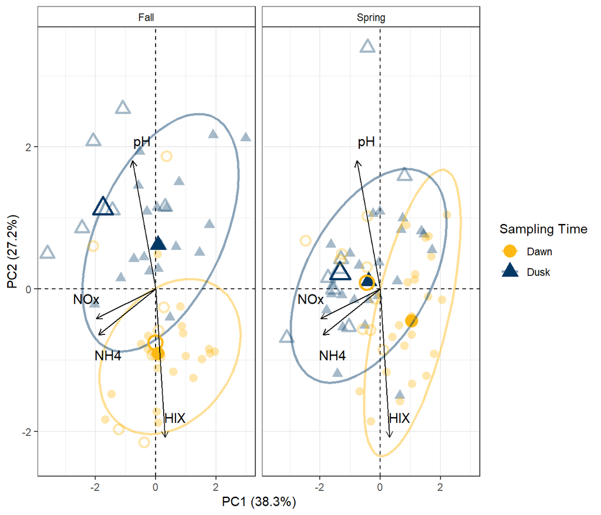

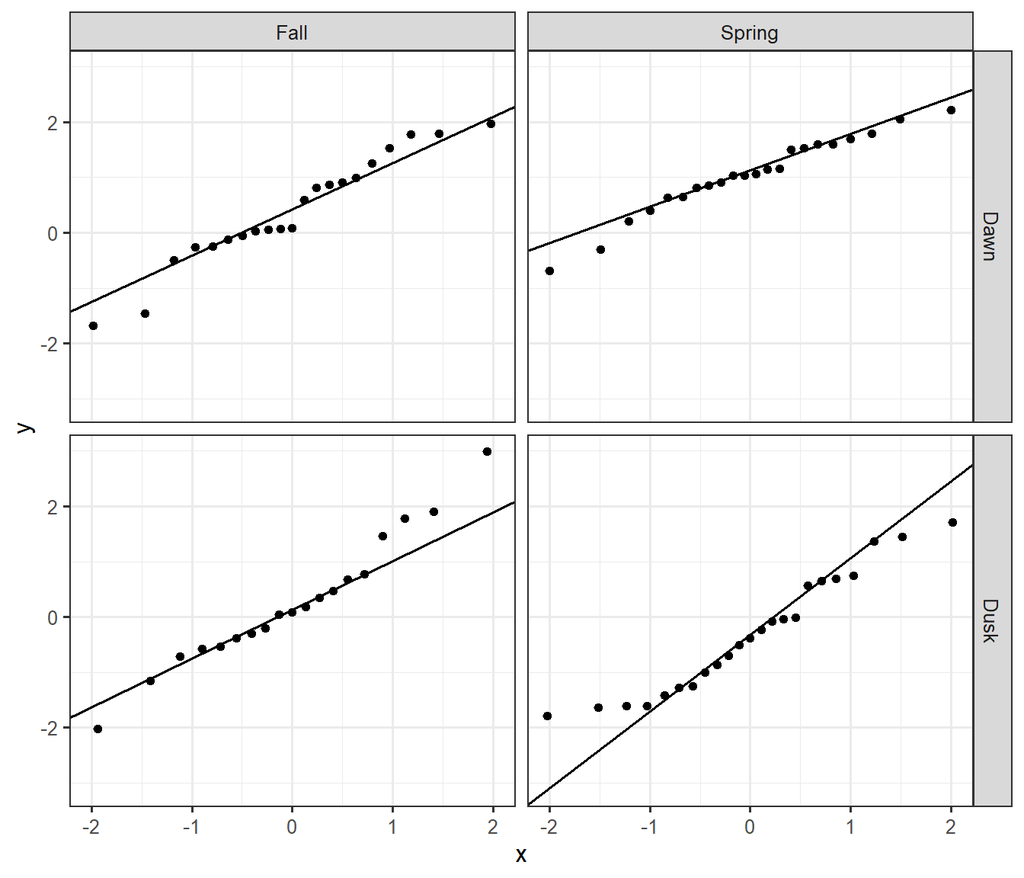

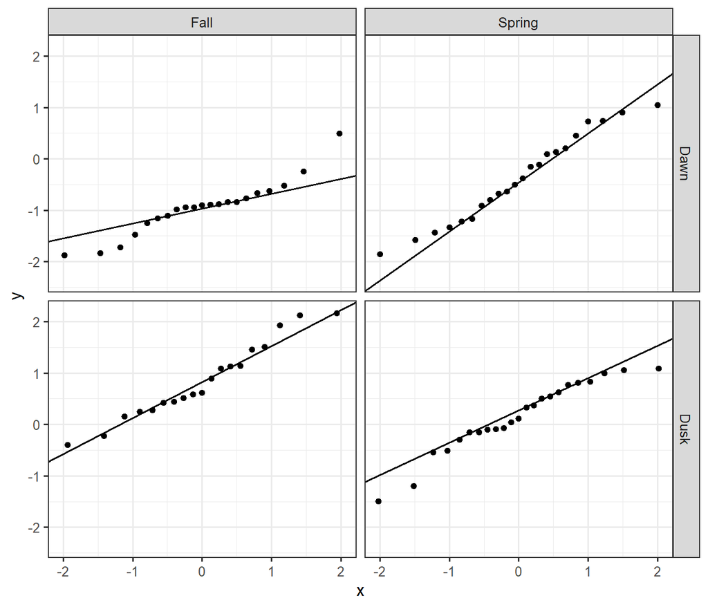

```
##
## [[4]]
##
##  Box's M-test for Homogeneity of Covariance Matrices
##
## data:  pca_scores
## Chi-Sq (approx.) = 12.6786, df = 9, p-value = 0.1777
##
##
## $manova
##                  Df  Pillai approx F num Df den Df    Pr(>F)
## Day_Night         1 0.57830   54.853      2     80 1.001e-15 ***
## Season            1 0.00346    0.139      2     80 0.8705715
## Day_Night:Season  1 0.17922    8.734      2     80 0.0003707 ***
## Residuals        81
## ---
## Signif. codes:  0 '***' 0.001 '**' 0.01 '*' 0.05 '.' 0.1 ' ' 1
##
## $season_manova
##   Season    Pillai Approx_F        p_val
## 1   Fall 0.7252217  48.8270 4.179991e-11
## 2 Spring 0.5464647  25.3029 6.149393e-08
```

```r
pca_biplot <- function(df,
                       vars,
                       season_var = "Season",
                       color_var = "Day_Night",
                       shape_var = "Day_Night",
                       ellipse_var = "Benthos",
                       control_label = "Surface Water") {

  # select vars of interest
  df_sub <- df %>%
    select(all_of(c(vars, season_var, color_var, ellipse_var)), sample_type) %>%
    drop_na(all_of(vars))

  # standardize within season
  df_scaled <- df_sub %>%
    group_by(.data[[season_var]]) %>%
    mutate(across(all_of(vars), scale)) %>%
    ungroup()

  # run PCA
  num_mat <- df_scaled %>%
    select(all_of(vars)) %>%
    as.matrix()

  pca_res <- prcomp(num_mat, scale. = FALSE)

  # get scores
  scores <- as.data.frame(pca_res$x[, 1:2])
  colnames(scores) <- c("PC1", "PC2")

  scores <- scores %>%
    bind_cols(
      df_scaled %>%
        select(all_of(c(season_var, color_var, ellipse_var)), sample_type)
    ) %>%
    mutate(Day_Night = factor(Day_Night, levels = c("Dawn", "Dusk")))

  # get loadings
  loadings <- as.data.frame(pca_res$rotation[, 1:2])
  colnames(loadings) <- c("PC1", "PC2")
  loadings$var <- rownames(loadings)

  # scale loadings
  mult <- min(
    diff(range(scores$PC1)) / diff(range(loadings$PC1)),
    diff(range(scores$PC2)) / diff(range(loadings$PC2))
  ) * 0.7

  loadings <- loadings %>%
    mutate(
      PC1 = PC1 * mult,
      PC2 = PC2 * mult
    )

  # variance
  var_expl <- (pca_res$sdev^2 / sum(pca_res$sdev^2)) * 100

  # medians for plot
  med <- scores %>%
    group_by_at(vars(one_of(c(season_var, color_var, shape_var)), "sample_type")) %>%
    summarise(
      PC1 = median(PC1, na.rm = TRUE),
      PC2 = median(PC2, na.rm = TRUE),
      .groups = "drop"
    )

# manova
  pca_scores <- scores %>%
    filter(sample_type == "Foundation Species") %>%
    select(
      PC1,
      PC2,
      Day_Night = all_of(color_var),
      Season   = all_of(season_var)
    )

  manova_res <- manova(cbind(PC1, PC2) ~ Day_Night * Season,
                       data = pca_scores)
  manova_summary <- summary(manova_res)

  # post-hoc: univariate ANOVAs
  univariate_anovas <- summary.aov(manova_res)

  # splitting by season
  within_season_manova <- pca_scores %>%
    group_split(Season) %>%
    map_dfr(function(d) {
      m_res <- manova(cbind(PC1, PC2) ~ Day_Night, data = d)
      s_res <- summary(m_res, test = "Pillai")$stats
      data.frame(
        Season = unique(d$Season),
        Pillai = s_res[1, "Pillai"],
        Approx_F = s_res[1, "approx F"],
        p_val = s_res[1, "Pr(>F)"]
      )
    })

  # check normality
  qq1 <- ggplot(pca_scores, aes(sample = PC1)) +
    stat_qq() +
    stat_qq_line() +
    facet_grid(Day_Night ~ Season)
  qq2 <- ggplot(pca_scores, aes(sample = PC2)) +
    stat_qq() +
    stat_qq_line() +
    facet_grid(Day_Night ~ Season)

  # check covariance
  boxbox <- boxM(cbind(PC1, PC2) ~ Day_Night * Season, data = pca_scores)

  # plot
    p <-
    ggplot() +

    geom_hline(yintercept = 0, linetype = "dashed") +
    geom_vline(xintercept = 0, linetype = "dashed") +

    # foundation species dots
    geom_point(
      data = scores %>% filter(sample_type == "Foundation Species"),
      aes_string(x = "PC1", y = "PC2", color = color_var, shape = shape_var),
      size = 3,
      alpha = 0.35
    ) +

    # median darker dot
    geom_point(
      data = med %>% filter(sample_type == "Foundation Species"),
      aes_string(x = "PC1", y = "PC2", color = color_var, shape = shape_var),
      size = 4.8,
      alpha = 1
    ) +

    # ellipses
    stat_ellipse(
      data = scores %>% filter(sample_type == "Foundation Species"),
      aes_string(x = "PC1", y = "PC2", group = color_var, color = color_var),
      linewidth = 1,
      alpha = 0.45,
      level = 0.95
    ) +

    # shape
    scale_shape_manual(values = c(16, 17), name = "Sampling Time") +

    # new shape for controls
    ggnewscale::new_scale("shape") +

    # control median
    geom_point(
      data = med %>% filter(sample_type == "Surface Water"),
      aes_string(x = "PC1", y = "PC2", color = color_var, shape = shape_var),
      size = 4.8,
      stroke = 1.5,
      alpha = 1,
      show.legend = FALSE
    ) +

    # control points
    geom_point(
      data = scores %>% filter(sample_type == "Surface Water"),
         aes_string(
             x = "PC1",
             y = "PC2",
            shape = shape_var,
            color = color_var
          ),
        fill  = NA,
        size = 3,
        stroke = 1.5,         # outline thickness
        alpha = .35,
        show.legend = FALSE
    ) +

    # open shapes for controls
    scale_shape_manual(values = c(21, 24)) +

    # colors for all points
    scale_color_manual(
      values = c("Dawn" = "#FDB813", "Dusk" = "#003865"),
      name = "Sampling Time"
    ) +

    # loadings
    geom_segment(
      data = loadings,
      aes(x = 0, y = 0, xend = PC1, yend = PC2),
      arrow = arrow(length = unit(0.2, "cm")),
      inherit.aes = FALSE
    ) +

    geom_text_repel(
      data = loadings,
      aes(x = PC1, y = PC2, label = var),
      size = 4,
      point.padding = 1,
      box.padding = 0.75,
      segment.color = "grey50",
      inherit.aes = FALSE
    ) +

    facet_wrap(as.formula(paste("~", season_var))) +

    labs(
      x = paste0("PC1 (", round(var_expl[1], 1), "%)"),
      y = paste0("PC2 (", round(var_expl[2], 1), "%)")
    ) +

    theme_bw()+
    theme(strip.background = element_rect(fill = "white"))

  return(list(
    p,
    qq1,
    qq2,
    boxbox,
    manova = manova_summary,
    season_manova = within_season_manova
  ))
}

pca_biplot(data_normal,
  vars      = less_vars,
  season_var = "Season",
  color_var = "Day_Night",
  shape_var = "Day_Night",
  ellipse_var = "Benthos")
```

## 6.2 Map

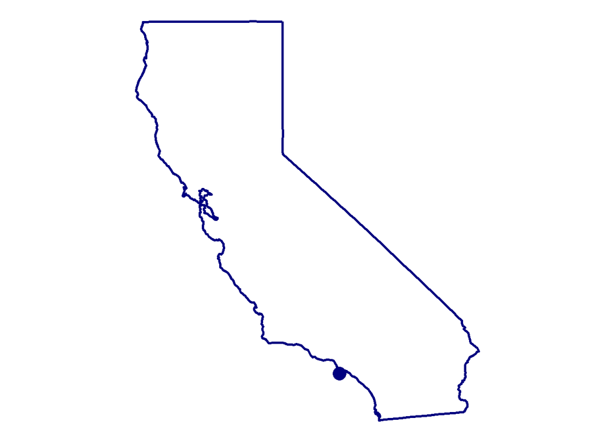

```r
states<-map_data("state") #all state coordinates
ca_data <- states %>%
  filter(region == "california") #just filter out california

ggplot()+
  geom_polygon(data = ca_data,
               aes(x=long, y=lat, group = group), color = "navyblue",
               fill = "white", linewidth = 1)+
  geom_point(aes(x = -118.294363, y = 33.704647), color= "navyblue", size = 5)+
  coord_map()+
  theme_void()
```

## 6.3 Temperature plots

### 6.3.1 Using HOBO data

Lower mean temperatures in Spring, but higher extreme temperatures/max.

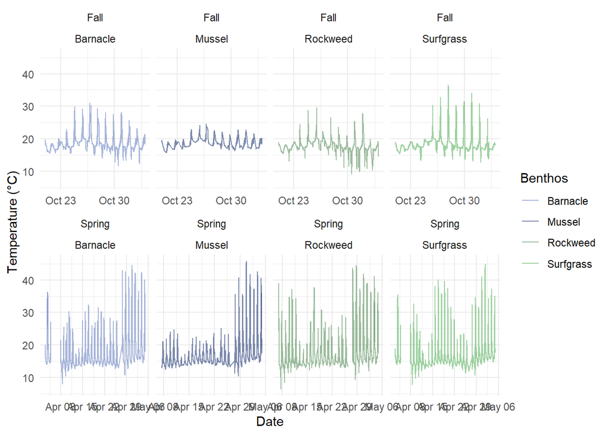

```r
# overall temperatures
ggplot(temperature,
       aes(x = datetime, y = temperature_c, color = Benthos)) +
  geom_line(alpha = 0.6, linewidth = 0.4) +
  labs(x = "Date", y = "Temperature (°C)") +
  scale_color_manual(values = c(
                     "Surfgrass" = "#5BB360",
                     "Rockweed" = "#5A8F5D",
                     "Barnacle" = "#6E86C2",
                     "Mussel" = "#233B75")) +
  facet_wrap(Season~Benthos,
             scale = "free_x",
             ncol = 4)+
  theme_minimal()
```

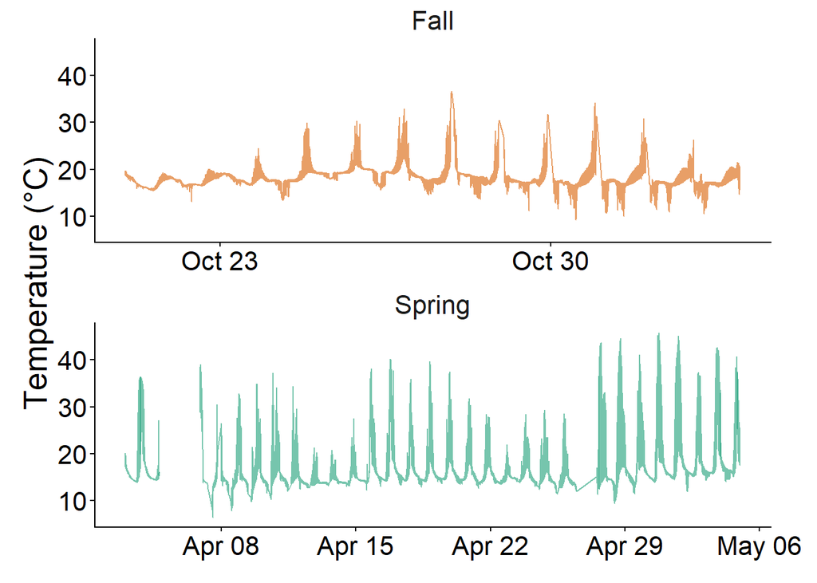

```r
# not faceted
ggplot(temperature, aes(x = datetime, y = temperature_c, color = Season)) +
  geom_line(alpha = 0.6, linewidth = 0.4) +
  labs(x = NULL, y = "Temperature (°C)") +
  scale_color_manual(values = c(
    "Fall"   = "#D95F02",
    "Spring" = "#1B9E77"
  )) +
  facet_wrap(~Season,
             scale = "free_x",
             ncol = 1)+
  theme_classic()+
  theme(legend.position = "none",
        strip.background = element_blank(),
        text = element_text(size = 20),
        plot.margin = unit(c(0,1,0.5,0.5), "cm"))
```

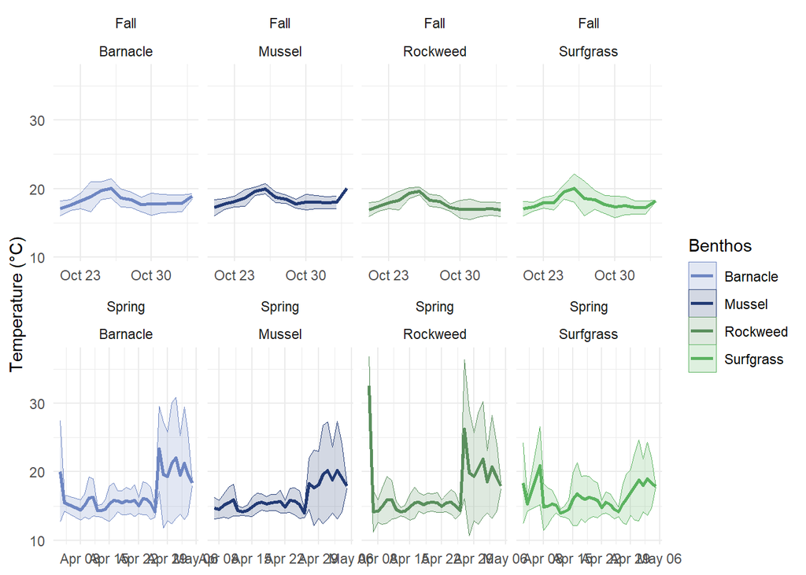

```r
# daily temperatures
temperature_summary <- temperature %>%
  mutate(Day = as.Date(datetime)) %>%
  group_by(Season, Benthos, Day) %>%
  summarise(
    temp_mean = mean(temperature_c, na.rm = TRUE),
    temp_sd   = sd(temperature_c, na.rm = TRUE),
    .groups = "drop"
  )

ggplot(temperature_summary,
       aes(Day, temp_mean, color = Benthos, fill = Benthos)) +
  geom_ribbon(aes(ymin = temp_mean - temp_sd,
                  ymax = temp_mean + temp_sd),
              alpha = 0.2, linewidth = 0) +
  geom_line(linewidth = 0.9) +
  scale_color_manual(values = c(
                     "Surfgrass" = "#5BB360",
                     "Rockweed" = "#5A8F5D",
                     "Barnacle" = "#6E86C2",
                     "Mussel" = "#233B75")) +
  scale_fill_manual(values = c(
                     "Surfgrass" = "#5BB360",
                     "Rockweed" = "#5A8F5D",
                     "Barnacle" = "#6E86C2",
                     "Mussel" = "#233B75")) +
  facet_wrap(Season~Benthos,
             scales = "free_x",
             ncol = 4) +
  labs(x = NULL, y = "Temperature (°C)") +
  theme_minimal()
```

```r
# statistical difference between seasons, but not benthos
tempmodel <- aov(temp_mean ~ Season * Benthos,
                 data = temperature_summary)
summary(tempmodel)
```

```
##                 Df Sum Sq Mean Sq F value   Pr(>F)
## Season           1   78.3   78.28  14.511 0.000195 ***
## Benthos          3   14.0    4.67   0.866 0.459909
## Season:Benthos   3   15.9    5.29   0.980 0.403399
## Residuals      168  906.3    5.39
## ---
## Signif. codes:  0 '***' 0.001 '**' 0.01 '*' 0.05 '.' 0.1 ' ' 1
```

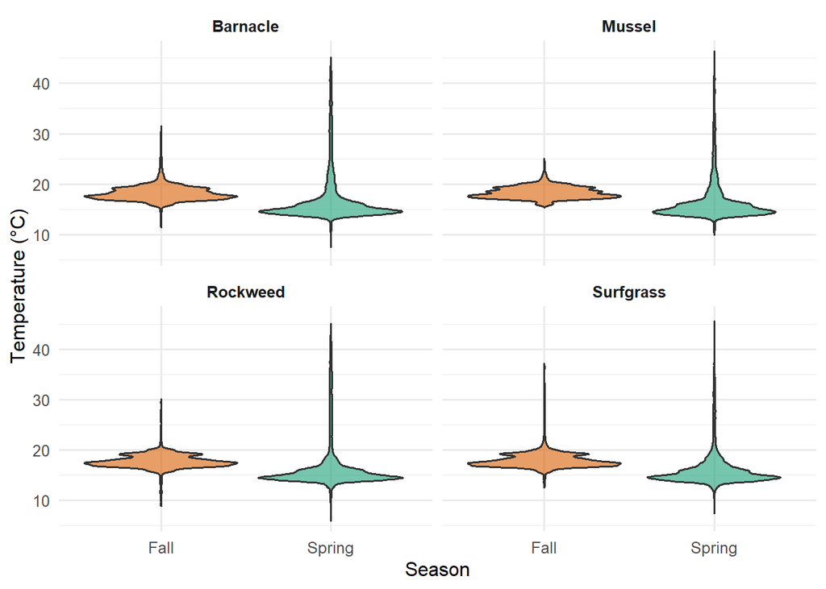

```r
# violin plot
ggplot(temperature,
       aes(x = Season, y = temperature_c, fill = Season)) +
  geom_violin(trim = FALSE, adjust = 1.2, alpha = 0.6) +
  scale_fill_manual(values = c(
    "Fall"   = "#D95F02",
    "Spring" = "#1B9E77"
  )) +
  facet_wrap(~ Benthos) +
  labs(
    y = "Temperature (°C)"
  ) +
  theme_minimal(base_size = 12) +
  theme(
    legend.position = "none",
    strip.text = element_text(face = "bold")
  )
```

### 6.3.2 Using buoy data

```r
tempplot <- ggplot(temp,
       aes(x = Season, y = WTMP, fill = Season)) +
  geom_violin(trim = FALSE, adjust = 1.2, alpha = 0.6) +
  scale_fill_manual(values = c(
    "Fall"   = "#D95F02",
    "Spring" = "#1B9E77"
  )) +
  labs(
    y = "Temperature (°C)"
  ) +
  theme_minimal(base_size = 12) +
  theme(
    legend.position = "none",
    text = element_text(size = 20),
    strip.text = element_text(face = "bold")
  )
```

## 6.4 CUTI plot

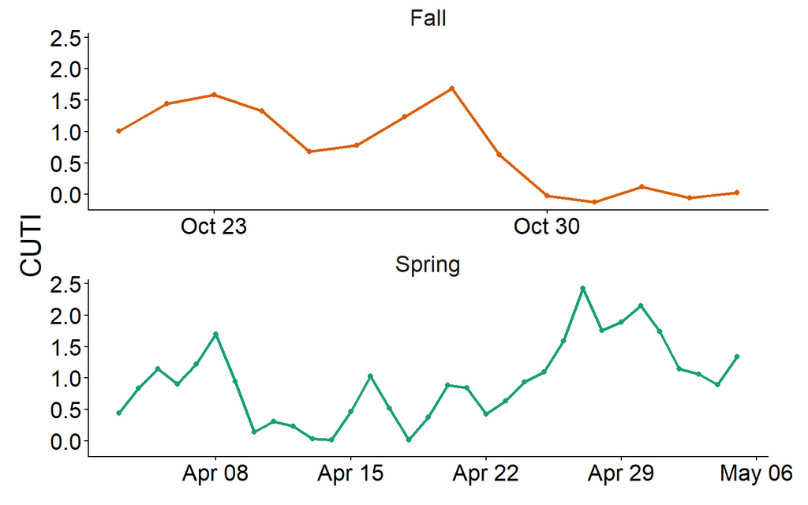

```r
ggplot(cuti, aes(x = Date, y = index, color = Season)) +
  geom_line(alpha = 1, linewidth = 1) +
  geom_point()+
  labs(x = NULL, y = "CUTI") +
  scale_color_manual(values = c(
    "Fall"   = "#D95F02",
    "Spring" = "#1B9E77"
  )) +
  facet_wrap(~Season,
             scale = "free_x",
             ncol = 1)+
  theme_classic()+
  theme(legend.position = "none",
        strip.background = element_blank(),
        text = element_text(size = 20),
        plot.margin = unit(c(0,1,0.5,0.5), "cm"))
```

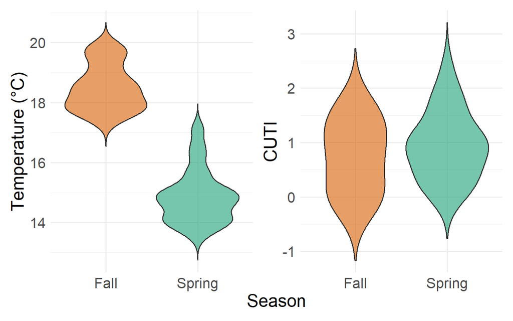

```r
cutiplot <- ggplot(cuti, aes(x = Season, y = index, fill = Season)) +
  geom_violin(trim = FALSE, adjust = 1.2, alpha = 0.6) +
  scale_fill_manual(values = c(
    "Fall"   = "#D95F02",
    "Spring" = "#1B9E77"
  )) +
  labs(
    y = "CUTI"
  ) +
  theme_minimal(base_size = 12) +
  theme(
    legend.position = "none",
    text = element_text(size = 20),
    strip.text = element_text(face = "bold"))

tempplot + cutiplot + plot_layout(axes = "collect")
```

## 6.5 Light plots

More light in spring, and barnacle and mussels higher on average than rockweeds and surfgrass.

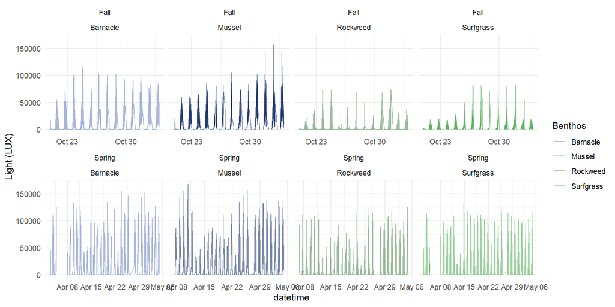

```r
# overall light lux
ggplot(temperature,
       aes(x = datetime, y = light_lux, color = Benthos)) +
  geom_line(alpha = 0.6, linewidth = 0.4) +
  labs(y = "Light (LUX)") +
  scale_color_manual(values = c(
                     "Surfgrass" = "#5BB360",
                     "Rockweed" = "#5A8F5D",
                     "Barnacle" = "#6E86C2",
                     "Mussel" = "#233B75")) +
  facet_wrap(Season~Benthos,
             scale = "free_x",
             ncol = 4)+
  theme_minimal()
```

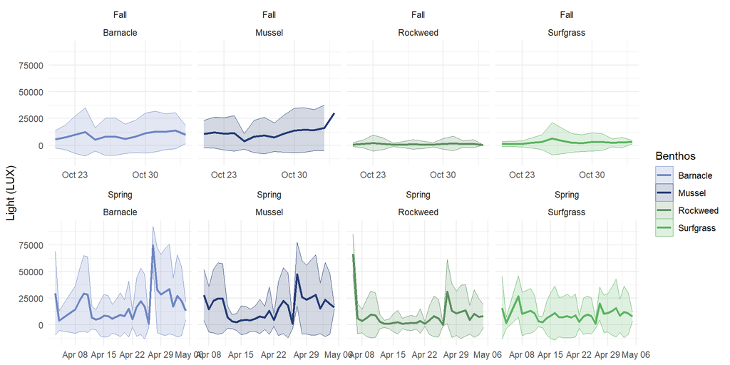

```r
# daily light lux
light_summary <- temperature %>%
  mutate(Day = as.Date(datetime)) %>%
  group_by(Season, Benthos, Day) %>%
  summarise(
    light_mean = mean(light_lux, na.rm = TRUE),
    light_sd   = sd(light_lux, na.rm = TRUE),
    .groups = "drop"
  )

# plot
ggplot(light_summary,
       aes(Day, light_mean, color = Benthos, fill = Benthos)) +
  geom_ribbon(aes(ymin = light_mean - light_sd,
                  ymax = light_mean + light_sd),
              alpha = 0.2, linewidth = 0) +
  geom_line(linewidth = 0.9) +
  scale_color_manual(values = c(
                     "Surfgrass" = "#5BB360",
                     "Rockweed" = "#5A8F5D",
                     "Barnacle" = "#6E86C2",
                     "Mussel" = "#233B75")) +
  scale_fill_manual(values = c(
                     "Surfgrass" = "#5BB360",
                     "Rockweed" = "#5A8F5D",
                     "Barnacle" = "#6E86C2",
                     "Mussel" = "#233B75")) +
  facet_wrap(Season~Benthos,
             scales = "free_x",
             ncol = 4) +
  labs(x = NULL, y = "Light (LUX)") +
  theme_minimal()
```

```r
# difference between season and benthos
lightmodel <- aov(light_mean ~ Season * Benthos,
                 data = light_summary)
summary(lightmodel)
```

```
##                 Df    Sum Sq   Mean Sq F value   Pr(>F)
## Season           1 1.759e+09 1.759e+09  19.132 2.13e-05 ***
## Benthos          3 3.157e+09 1.052e+09  11.444 7.24e-07 ***
## Season:Benthos   3 1.473e+08 4.910e+07   0.534     0.66
## Residuals      168 1.545e+10 9.195e+07
## ---
## Signif. codes:  0 '***' 0.001 '**' 0.01 '*' 0.05 '.' 0.1 ' ' 1
```

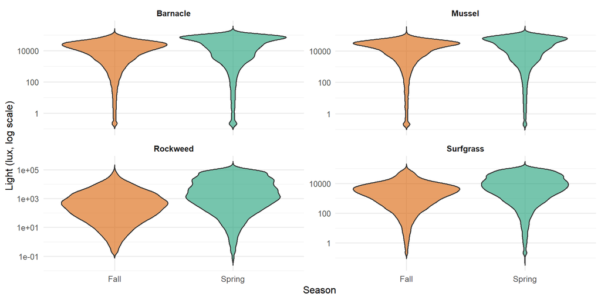

```r
# violin plot
ggplot(temperature,
       aes(x = Season, y = light_lux, fill = Season)) +
  geom_violin(trim = FALSE, alpha = 0.6) +
  scale_fill_manual(values = c(
    "Fall"   = "#D95F02",
    "Spring" = "#1B9E77"
  )) +
  facet_wrap(~ Benthos, scales = "free_y") +
  scale_y_log10() +
  labs(
    y = "Light (lux, log scale)"
  ) +
  theme_minimal(base_size = 12) +
  theme(
    legend.position = "none",
    strip.text = element_text(face = "bold")
  )
```